# Crimes in San Francisco (2003 - 2015)

Kunal Kumar

## Overview

This is an ongoing exploratory data analysis of recorded crimes that occurred in San Francisco (SF) between Jan 1,2003 and May 13, 2015. This data set was obtained from [SF Open Data](https://data.sfgov.org/) via the Kaggle [SF Crime Classification](https://www.kaggle.com/c/sf-crime) challenge.

## Data

We will use the train.csv file provided by Kaggle. The original problem requires one to build a model using data from alternate weeks in the 2003-15 time period, and use it to predict crime categories for events in the test.csv file. These events occur in the alternate weeks that are missing from the train.csv file.

Let’s explore the data in train.csv

```r
## load packages
  library(lubridate)  ## manipulating dates
  library(reshape2)   ## manipulating dataframes
  library(TSA)   ## for time series analysis
  library(ggplot2) ## pretty plots

## load data from train.csv. Convert column headings to lower case.
  traindf <- read.csv("train.csv")
  names(traindf) <- tolower(names(traindf))
  names(traindf)
```

```
## [1] "dates"      "category"   "descript"   "dayofweek"  "pddistrict"
## [6] "resolution" "address"    "x"          "y"
```

In train.csv there are 9 fields for each event. Let’s get a sense of what these fields are used to record.

```r
  str(traindf)
```

```
## 'data.frame':    878049 obs. of  9 variables:
##  $ dates     : Factor w/ 389257 levels "2003-01-06 00:01:00",..: 389257 389257 389256 389255 389255 389255 389255 389255 389254 389254 ...
##  $ category  : Factor w/ 39 levels "ARSON","ASSAULT",..: 38 22 22 17 17 17 37 37 17 17 ...
##  $ descript  : Factor w/ 879 levels "ABANDONMENT OF CHILD",..: 867 811 811 405 405 407 740 740 405 405 ...
##  $ dayofweek : Factor w/ 7 levels "Friday","Monday",..: 7 7 7 7 7 7 7 7 7 7 ...
##  $ pddistrict: Factor w/ 10 levels "BAYVIEW","CENTRAL",..: 5 5 5 5 6 3 3 1 7 2 ...
##  $ resolution: Factor w/ 17 levels "ARREST, BOOKED",..: 1 1 1 12 12 12 12 12 12 12 ...
##  $ address   : Factor w/ 23228 levels "0 Block of  HARRISON ST",..: 19791 19791 22698 4267 1844 1506 13323 18055 11385 17659 ...
##  $ x         : num  -122 -122 -122 -122 -122 ...
##  $ y         : num  37.8 37.8 37.8 37.8 37.8 ...
```

To make it easier to spot patterns in the data, it will be useful to create columns for week number, month number, and year for each event.

```r
  ## column 1 is the dates column.
  weeknum <- week(traindf[,1])
  ## Note : train set weeks and week() are out of phase. Thus the train set
  ## has all week numbers and not just alternate week numners.

  monthnum <- month(traindf[,1])
  year <- year(traindf[,1])

  traindf <- cbind(traindf, weeknum, monthnum, year)
```

Let’s plot the total number of crimes each year.

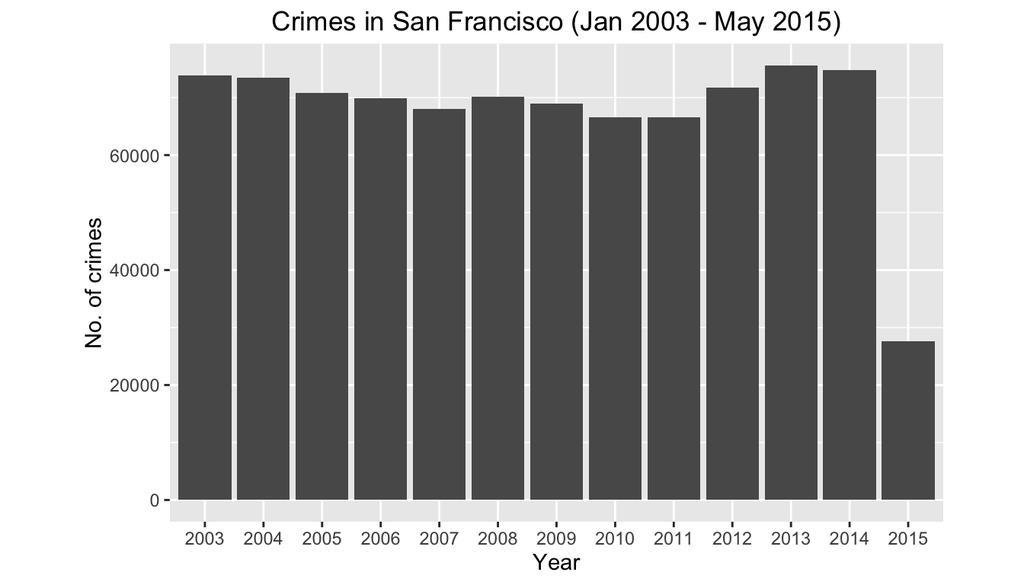

```r
  goldenratio <- 1.618
  p <- qplot(factor(year),data = traindf, geom = "bar", xlab = "Year", ylab = "No. of crimes", main = "Crimes in San Francisco (Jan 2003 - May 2015)")
  p + theme(aspect.ratio = 1/goldenratio)
```

There is a downward trend from 2003-2011, and then the number of crimes picks up to reach around 2003 levels. Note that only the first five months of data from 2015 are included. This explains the significantly small bar corresponding to 2015.

Let’s take a look at the monthly counts in all crimes over the time period Jan 2003 - April2015. (We will skip May 2015 as data is available only for half the month).

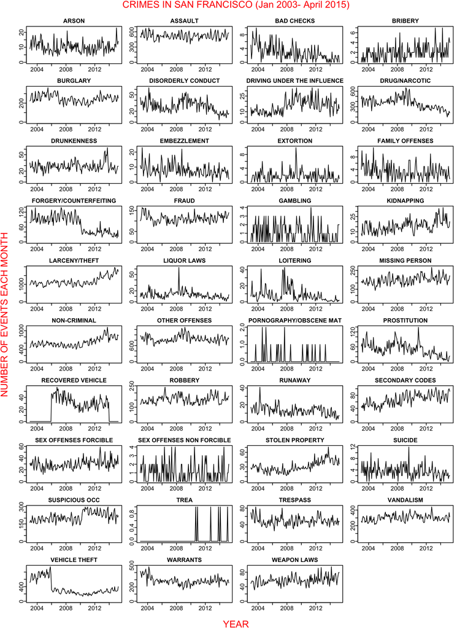

```r
  monthtot <- traindf[,c("dates","category","monthnum","year")]

  ## Finding number of events per month for each category and month in 2003-2014.
  categmonthtot <- tapply(monthtot$monthnum, list(monthtot$category, monthtot$monthnum,
                                                  monthtot$year), function(x) length(x))
  categmonthtot <- melt(categmonthtot)

  ## replacing NA with 0
  categmonthtot$value[is.na(categmonthtot$value)] <- 0
  names(categmonthtot) <- c("category","monthnum","year","numevt")

  ## Character Vector of category names
  categvec <- as.character(unique(categmonthtot$category))

  ## this plot will be made using the base plot system. Setting parameters for ach panel of the figure.
  par(mfrow = c(10,4), mar = c(1.5,1.5,1.5,.5),oma = c(2,2,2,0), tcl = -0.3, mgp = c(0,0.2,0), cex.main = 0.95, cex.axis = 0.95)

  ## Create and plot a time series for each of the 39 categories of crime
  for(i in 1:39){ tmp.ts <- ts(subset(categmonthtot$numevt, categmonthtot$category == categvec[i]),frequency = 12, start = c(2003,1), end = c(2015,4)); plot.ts(tmp.ts, ylim = c(0,max(tmp.ts)),main = categvec[i], xlab = "",ylab ="") }

  mtext("YEAR", side = 1, outer = T, cex = 1, line = 1, col = "RED")
  mtext("NUMBER OF EVENTS EACH MONTH", side = 2, outer = T, cex = 1, line = 0.8, col = "RED")
  mtext("CRIMES IN SAN FRANCISCO (Jan 2003- April 2015)", side = 3, outer = T, cex = 1, line = 0.8, col = "RED")
```

## Interesting Features

An interesting feature in some of the plots are level changes. For example, there is a clear dip in forgery/counterfeiting around 2010. The same feature is seen in “VEHICLE THEFT” around 2006. We could speculate that it is related to some change in book-keeping because we see an opposite level change (though of smaller magnitude) in “RECOVERED VEHICLE”. There also seems to be a level increase in “DRIVING UNDER THE INFLUENCE” at the start of 2008.

Another interesting feature is an isolated peak. The best example (and perhaps only) of this seems to be the spike a little after 2008 in “LIQUOR LAWS”. It seems unlikely that this peak is just an upward statistical fluctuation.

## Reduction in FORGERY/COUNTERFEITING in 2010

We will investigate the reduction in cases of “Forgery/Counterfeiting” around 2010. To get a better sense of when the level change occurred let’s look at this category of crimes closely.

```r
  forgery <- subset(traindf, category =="FORGERY/COUNTERFEITING")
  table(list(forgery$monthnum, forgery$year))
```

```
##     .2
## .1   2003 2004 2005 2006 2007 2008 2009 2010 2011 2012 2013 2014 2015
##   1    78   98  104  129   99   91   70   92   37   29   19   58   33
##   2    77   80   75   81   81   67   85   63   31   24   27   39   16
##   3    81  115   91   98  106  100  103   43   33   27   33   31   47
##   4   129  115   80   66  120  111  131   30   29   33   34   32   22
##   5   120   98   83  111  139  120  126   33   48   57   54   33    9
##   6    84   71  101  122  131  112   85   47   28   38   44   20    0
##   7    91   80  106  127   94  108   70   52   36   45   55   22    0
##   8    92   91   70   90   96   79   92   46   33   42   37   19    0
##   9    90  103   83   79   86  110  106   38   41   36   41   37    0
##   10  138  106   80   83  129  123   98   34   29   83   48   33    0
##   11   84   75  102  112  109   98   82   43   35   38   36   21    0
##   12   77   91  108  116  110   82   70   38   35   47   31   25    0
```

From the earlier plot and the above table, we can reasonably assume that the level change occurred around Feb/March 2010. Let’s look at the data from a year prior and post to see what changed.

```r
 # using data one year before level change vs data for yr after
  forgerypre <- subset(forgery, (year == 2009 & monthnum >2) |
                         (year == 2010 & monthnum <=2))
  forgerypost <- subset(forgery, (year == 2010 & monthnum >2) |
                          (year == 2011 & monthnum <= 2))
```

To focus on the subcategory of the crime we can choose to look only at the **descript** field for now.

```r
  forgerypredesc<- table(forgerypre$descript)
  forgerypostdesc<- table(forgerypost$descript)

  ##Let's get rid of entries that are zero.
  forgerypredesc <- forgerypredesc[!(forgerypredesc == 0)]
  forgerypostdesc <- forgerypostdesc[!(forgerypostdesc == 0)]
```

We can plot the number of crimes by sub-category and see where the main changes occurred. We can use a simple bar-plot. But first we must ensure that we have the same sub-categories in both tables, and if not we can add some zero entries.

```r
  names(forgerypredesc)
```

```
##  [1] "CHECKS OR LEGAL INSTRUMENTS, UTTERING FORGED"
##  [2] "CHECKS, FORGERY (FELONY)"
##  [3] "CHECKS, FORGERY (MISDEMEANOR)"
##  [4] "CHECKS, MAKE OR PASS FICTITIOUS"
##  [5] "CHECKS, POSSESSION WITH INTENT TO PASS"
##  [6] "COUNTERFEITING, COINS OR NOTES"
##  [7] "COUNTERFEITING, POSSESSION COINS OR NOTES"
##  [8] "FALSIFYING JUDICIAL & PUBLIC RECORDS & DOCUMENTS"
##  [9] "FORGERY & COUNTERFEITING (GENERAL)"
## [10] "FORGERY, DRIVERS LICENSE OR ID-CARD"
## [11] "FORGERY, FALSE ENTRIES IN RECORDS OR RETURNS"
## [12] "FORGERY, GOVERNMENT OR CORPORATE SEALS"
## [13] "FORGERY, NOTES"
## [14] "FORGERY, POSSESSION DRIVERS LICENSE OR ID-CARD"
## [15] "MONEY, CHANGING FACE AMOUNT"
```

```r
  names(forgerypostdesc)
```

```
##  [1] "CHECKS OR LEGAL INSTRUMENTS, UTTERING FORGED"
##  [2] "CHECKS, FORGERY (FELONY)"
##  [3] "CHECKS, MAKE OR PASS FICTITIOUS"
##  [4] "CHECKS, POSSESSION WITH INTENT TO PASS"
##  [5] "CITIZENSHIP DOCUMENT, USING FALSE"
##  [6] "CITIZENSHIP OR ALIEN REGISTRATION, MAKING FALSE DOCUMENT"
##  [7] "COUNTERFEITING, COINS OR NOTES"
##  [8] "COUNTERFEITING, PLATES OR DIES"
##  [9] "COUNTERFEITING, POSSESSION COINS OR NOTES"
## [10] "FALSIFYING JUDICIAL & PUBLIC RECORDS & DOCUMENTS"
## [11] "FINANCIAL STATEMENTS, FALSE"
## [12] "FORGERY & COUNTERFEITING (GENERAL)"
## [13] "FORGERY, DRIVERS LICENSE OR ID-CARD"
## [14] "FORGERY, FALSE ENTRIES IN RECORDS OR RETURNS"
## [15] "FORGERY, GOVERNMENT OR CORPORATE SEALS"
## [16] "FORGERY, NOTES"
## [17] "FORGERY, POSSESSION DRIVERS LICENSE OR ID-CARD"
## [18] "IDENTIFICATION, GOVERNMENT, POSSESS, MAKE OR SELL FALSE"
## [19] "MANUFACTURE OR SALE OF COUNTERFEIT GOODS"
## [20] "MONEY, CHANGING FACE AMOUNT"
## [21] "TELEPHONE OR TELEGRAPH MESSAGE, SENDING FALSE"
```

```r
  forgerypredesc["CITIZENSHIP DOCUMENT, USING FALSE"] <- 0
  forgerypredesc["CITIZENSHIP OR ALIEN REGISTRATION, MAKING FALSE DOCUMENT"] <- 0
  forgerypredesc["COUNTERFEITING, PLATES OR DIES"] <- 0
  forgerypredesc["FINANCIAL STATEMENTS, FALSE"] <- 0
  forgerypredesc["IDENTIFICATION, GOVERNMENT, POSSESS, MAKE OR SELL FALSE"] <- 0
  forgerypredesc["MANUFACTURE OR SALE OF COUNTERFEIT GOODS"] <- 0
  forgerypredesc["TELEPHONE OR TELEGRAPH MESSAGE, SENDING FALSE"] <- 0

  forgerypostdesc["CHECKS, FORGERY (MISDEMEANOR)"] <- 0

  forgerypredesc <- forgerypredesc[order(names(forgerypredesc))]
  forgerypostdesc <- forgerypostdesc[order(names(forgerypostdesc))]
```

Let’s plot the number of events and see which sub-categories were driving the reduction.

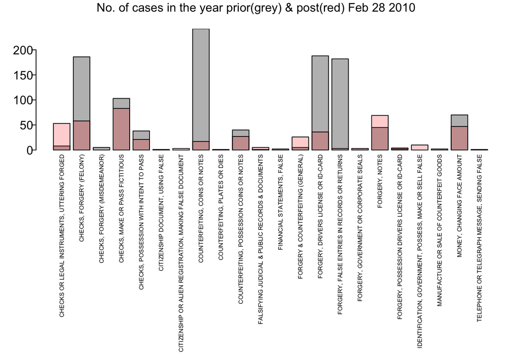

```r
  par(mar = c(14,2,0,0), oma = c(0.5,0.5,2,0), mgp = c(0,0.2,0), tcl = -0.3)

  ## Plotting numbers pre Feb 2010 (including Feb 2010)
  barplot(forgerypredesc, cex.names = 0.5, las = 2, xaxt = "n",yaxt = "n")

  ## Plotting numbers from post Feb 2010
  barplot(forgerypostdesc, cex.names = 0.5,
          las = 2, col = rgb(1,0,0,alpha = 0.2), add = T)

  mtext("No. of cases in the year prior(grey) & post(red) Feb 28 2010",
        side = 3, line = 1, outer = T)
```

We see from the bar-plot that the following sub-categories saw drastic reductions (of order 100 events):

- CHECKS, FORGERY (FELONY)
- COUNTERFEITING, COINS OR NOTES
- FORGERY, DRIVERS LICENSE OR ID-CARD
- FORGERY, FALSE ENTRIES IN RECORDS OR RETURNS

Teasing out why these numbers reduced will require further investigation. The next step would be to look at the ways these events were resolved.